# Лабораторная работа №4: Вставка изображений

Дисциплина: Компьютерный практикум по научному письму

ДАБВАН ЛУАИ МОХАММЕД АЛИ, НФИмд-01-24, 1032249837

Российский университет дружбы народов, Москва, Россия

25 октября 2025

## Преподаватель

**ФИО:** Кулябов Дмитрий Сергеевич **Должность:** Профессор кафедры прикладной информатики и теории вероятностей РУДН **Дисциплина:** Компьютерный практикум по научному письму

## Информация о докладчике

Дабвван Луаи Мохаммед Али Студент 2 курса Направление: 02.04.02 Фундаментальная информатика и информационные технологии (магистратура) Российский университет дружбы народов

# Вводная часть

### Актуальность темы:

Использование изображений является важным элементом научных публикаций и презентаций. Пакет graphicx в LaTeX обеспечивает гибкое управление графикой, её масштабированием, обрезкой и позиционированием.

### Объект исследования:

Документы, подготовленные с использованием LaTeX.

### Предмет исследования:

Методы включения и форматирования графических элементов в LaTeX.

### Научная новизна:

Систематизация способов управления графическими элементами и анализ возможностей пакета graphicx в контексте научной работы.

### Практическая значимость:

Позволяет создавать профессионально оформленные отчёты, статьи и диссертации с корректным размещением изображений.

# Цель работы , задачи и гипотеза

## Цель исследования:

Изучить методы вставки изображений в LaTeX с помощью пакета graphicx

## Гипотеза:

Использование команд LaTeX для вставки изображений позволяет добиться профессионального качества оформления научных документов.

## Задачи исследования:

1. Ознакомиться с основными командами \includegraphics и параметрами (width, height, scale, angle).
2. Изучить способы позиционирования изображений с помощью среды figure.
3. Рассмотреть методы обрезки и масштабирования графики.
4. Освоить кросс-ссылки на рисунки и автоматическую нумерацию.
5. Выполнить упражнение 4.9 из практического руководства

## Материалы и методы

- Пакет: graphicx
- Среда: figure
- Дополнительные инструменты: float, trivfloat, hyperref
- Теоретическая база: раздел 4 книги Practical Scientific Writing

# Содержание исследования

## 1.Предлагаемое решение задач исследования с обоснованием

Для решения поставленных задач исследования была выбрана система вёрстки LaTeX и пакет graphicx, предоставляющий широкий набор инструментов для работы с графикой. Основная идея заключалась в интеграции графических элементов в научный текст без потери качества изображения и с сохранением логической структуры документа.

Обоснование выбора данного подхода связано с его гибкостью, универсальностью и соответствием академическим стандартам оформления научных публикаций.

# 2.Основные этапы работы

## пражнение 1. Вставить собственное изображение.

```latex
\section*{Упражнение 1: Включение изображений}
\begin{figure}[H]
\centering
\includegraphics[width=0.3\textwidth]{image.jpg}
\caption{Мое изображение}
\label{fig:myimage}
\end{figure}
```

## Результат:

[figure not shown]

## Упражнение 2. Использование параметров height, width, angle, scale

мы изучили влияние параметров изменения размера и угла поворота изображения.

```latex
\section*{Упражнение 2: Параметры изображений}

\begin{center}
\includegraphics[height=2cm]{image.jpg}
\includegraphics[width=0.2\textwidth]{image.jpg}
\includegraphics[scale=0.6]{image.jpg}
\includegraphics[angle=45, width=0.15\textwidth]{image.jpg}
\end{center}
```

## Результат:

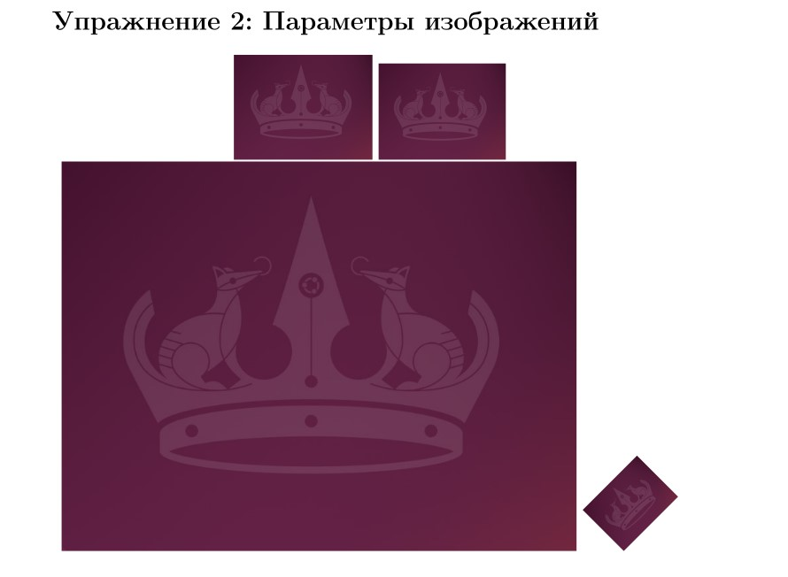

## Упражнение 3. Сравнение `latex \textwidth и \linewidth` с опцией twocolumn

`Использовать ключ width для задания размеров двух изображений — одно относительно \textwidth, другое относительно \linewidth. Затем проверить, как они ведут себя в обычном режиме и при включении параметра twocolumn.`

```latex
\clearpage
\twocolumn

\section*{Упражнение 3: Сравнение \textbackslash textwidth и \textbackslash linewidth}

\begin{figure}[h!]
\centering
\includegraphics[width=0.8\textwidth]{image.jpg}
\includegraphics[width=0.8\linewidth]{image.jpg}
```

## Упражнение 3. Сравнение `latex \textwidth и \linewidth` с опцией twocolumn

```latex
\caption{Сравнение textwidth и linewidth в режиме двух колонок}
\end{figure}

\onecolumn
\clearpage

\begin{figure}[h!]
\centering
\includegraphics[width=0.8\textwidth]{image.jpg}
\includegraphics[width=0.8\linewidth]{image.jpg}
\caption{В одноколоночном режиме}
\end{figure}
```

## Результат:

[figure not shown]

[figure not shown]

## Упражнение 4. Использование lipsum и размещение плавающих объектов

```latex
\newpage


\section*{Упражнение 4: Работа с плавающими объектами}

\lipsum[1-2]

\begin{figure}[H]
\centering
\includegraphics[width=0.3\textwidth]{image.jpg}
\caption{Рисунок с [H] - точно здесь}
\label{fig:here}
\end{figure}
latex
```

## Упражнение 4. Использование lipsum и размещение плавающих объектов

```latex
\lipsum[3]

\begin{figure}[H]
\centering
\includegraphics[width=0.3\textwidth]{image.jpg}
\caption{Рисунок в текущем месте}
\label{fig:current}
\end{figure}


\lipsum[4]

\begin{figure}[t]
\centering
\includegraphics[width=0.4\textwidth]{image.jpg}
\caption{Рисунок с [t] - верх страницы}
\label{fig:top}
\end{figure}
```

## Упражнение 4. Использование lipsum и размещение плавающих объектов

```latex
\begin{figure}[b]
\centering
\includegraphics[width=0.4\textwidth]{image.jpg}
\caption{Рисунок с [b] - низ страницы}
\label{fig:bottom}
\end{figure}

\clearpage
```

## Результат:

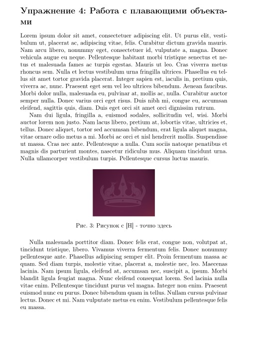

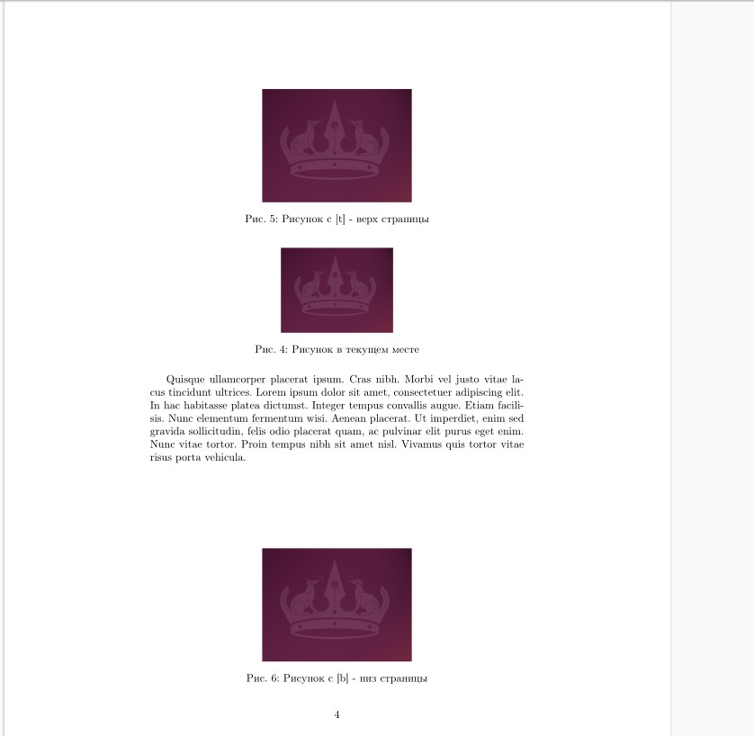

## Упражнение 5. Добавление нумерованных разделов и проверка количества прогонов LaTeX

```latex
\section*{Упражнение 5: Перекрестные ссылки}

\section{Введение}
\label{sec:intro}
```

```latex
Это раздел введения. Мы будем ссылаться на него позже.

\subsection{Теоретическая основа}
\label{subsec:background}

Этот подраздел обсуждает теоретическую основу.

\begin{enumerate}
    \item \label{item:first} Первый важный пункт
    \item \label{item:second} Второй важный пункт
    \item \label{item:third} Третий важный пункт
\end{enumerate}
```

```latex
\begin{equation}
\label{eq:simple}
E = mc^2

\end{equation}


Теперь мы можем ссылаться на различные элементы:

\begin{itemize}
    \item Раздел: \ref{sec:intro}

    \item Подраздел: \ref{subsec:background}
    \item Первый пункт: \ref{item:first}
    \item Уравнение: \ref{eq:simple}
    \item Рисунок 1: \ref{fig:myimage}

    \item Рисунок 3: \ref{fig:linewidth}
\end{itemize}

Как обсуждалось в разделе~\ref{sec:intro}, особенно в пункте~\ref{item:first}, мы видим из уравнения~\ref{eq:simple} что...
```

## Результат:

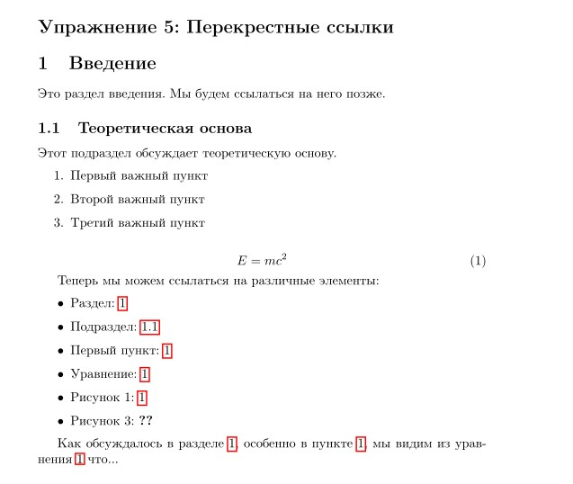

## Упражнение 6. Проверка работы после \end{equation}

```latex
\section*{Упражнение 6: Метки уравнений}

\begin{equation}
E = mc^2
\label{eq:energy}
\end{equation}

\begin{equation}
E = mc^2
\end{equation}
\label{eq:energy}
```

## Результат:

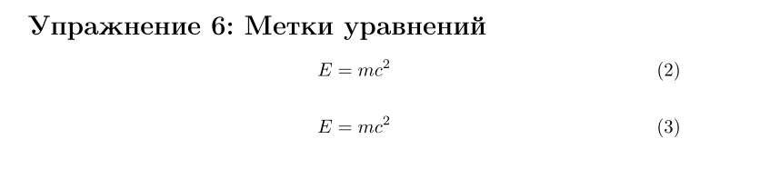

# Анализ и практическая значимость достигнутых результатов

В ходе выполнения практической работы по теме «Including Graphics» были проведены серии упражнений, направленных на изучение инструментов LaTeX для работы с графикой, нумерацией и перекрёстными ссылками.

## Анализ полученных результатов показывает следующее:

Гибкость системы. Пакет graphicx обеспечивает широкие возможности управления изображениями — масштабирование, вращение, обрезку и позиционирование без потери качества.

Точность позиционирования. Использование параметров `\textwidth и \linewidth` демонстрирует разницу в поведении графических объектов в одно- и двухколоночных макетах, что имеет практическое значение при подготовке статей и отчётов в формате журнала.

## Практическая значимость работы заключается в том, что освоенные методы позволяют:

грамотно оформлять научные публикации, диссертации и отчёты;

повышать визуальную наглядность материалов за счёт интеграции графики;

избегать ошибок при нумерации и ссылках, что важно при подготовке больших документов.

# Выводы по проделанной работе

LaTeX остаётся надёжной и универсальной системой для подготовки научных документов высокого качества.

Грамотное использование графики способствует лучшему восприятию данных и повышает академический уровень оформления публикаций.

Полученные навыки можно применять при написании научных статей, дипломных и проектных работ, а также при подготовке отчётов и презентаций.